# Supervised Learning Assignment

### Student Name: Ramnath Natarajan

### Course Name: AIML

### Batch: April'2020-B (Group 5)

```python
#Some notes related to Python commands, etc. are given as comments
#Task numbers (in line with Problem Statement PDF) are given as Markdown cell
#Inference or statements (if any) after running a cell are given as Markdown cell
```

### 1) Reading each column and understanding the data (includes data pre-processing)

```python
# Importing libraries for understanding data & its distribution
import pandas as pd
import matplotlib.pyplot as plt
import seaborn as sns
sns.set(color_codes=True)
import numpy as np
import scipy.stats as stats
```

```python
# Reading data from data set (first ten rows shown as example)

loan=pd.read_csv('Bank_Personal_Loan_Modelling.csv')
loan
```

|  | ID | Age | Experience | Income | ZIP Code | Family | CCAvg | Education | Mortgage | Personal Loan | Securities Account | CD Account | Online | CreditCard |
| --- | --- | --- | --- | --- | --- | --- | --- | --- | --- | --- | --- | --- | --- | --- |
| 0 | 1 | 25 | 1 | 49 | 91107 | 4 | 1.6 | 1 | 0 | 0 | 1 | 0 | 0 | 0 |
| 1 | 2 | 45 | 19 | 34 | 90089 | 3 | 1.5 | 1 | 0 | 0 | 1 | 0 | 0 | 0 |
| 2 | 3 | 39 | 15 | 11 | 94720 | 1 | 1.0 | 1 | 0 | 0 | 0 | 0 | 0 | 0 |
| 3 | 4 | 35 | 9 | 100 | 94112 | 1 | 2.7 | 2 | 0 | 0 | 0 | 0 | 0 | 0 |
| 4 | 5 | 35 | 8 | 45 | 91330 | 4 | 1.0 | 2 | 0 | 0 | 0 | 0 | 0 | 1 |
| ... | ... | ... | ... | ... | ... | ... | ... | ... | ... | ... | ... | ... | ... | ... |
| 4995 | 4996 | 29 | 3 | 40 | 92697 | 1 | 1.9 | 3 | 0 | 0 | 0 | 0 | 1 | 0 |
| 4996 | 4997 | 30 | 4 | 15 | 92037 | 4 | 0.4 | 1 | 85 | 0 | 0 | 0 | 1 | 0 |
| 4997 | 4998 | 63 | 39 | 24 | 93023 | 2 | 0.3 | 3 | 0 | 0 | 0 | 0 | 0 | 0 |
| 4998 | 4999 | 65 | 40 | 49 | 90034 | 3 | 0.5 | 2 | 0 | 0 | 0 | 0 | 1 | 0 |
| 4999 | 5000 | 28 | 4 | 83 | 92612 | 3 | 0.8 | 1 | 0 | 0 | 0 | 0 | 1 | 1 |

5000 rows × 14 columns

```python
# Checking size of data

shape_loan=loan.shape
size_loan=loan.size
print("Number of rows, columns in data set:",shape_loan)
print("Total number of data points are",size_loan)
```

```
Number of rows, columns in data set: (5000, 14)
Total number of data points are 70000
```

```python
# Understanding data types in given data frame

loan.info()
```

```
<class 'pandas.core.frame.DataFrame'>
RangeIndex: 5000 entries, 0 to 4999
Data columns (total 14 columns):
 #   Column              Non-Null Count  Dtype
---  ------              --------------  -----
 0   ID                  5000 non-null   int64
 1   Age                 5000 non-null   int64
 2   Experience          5000 non-null   int64
 3   Income              5000 non-null   int64
 4   ZIP Code            5000 non-null   int64
 5   Family              5000 non-null   int64
 6   CCAvg               5000 non-null   float64
 7   Education           5000 non-null   int64
 8   Mortgage            5000 non-null   int64
 9   Personal Loan       5000 non-null   int64
 10  Securities Account  5000 non-null   int64
 11  CD Account          5000 non-null   int64
 12  Online              5000 non-null   int64
 13  CreditCard          5000 non-null   int64
dtypes: float64(1), int64(13)
memory usage: 547.0 KB
```

Above result shows the following

a) Data frame contains Integer and Float data types only

b) Non-null count for each column matches with number of rows in data frame.This means that there are no null values. This can be verified again by'isnull()' command as shown below

```python
# Checking for null values

loan.isnull().any()
```

```
ID                    False
Age                   False
Experience            False
Income                False
ZIP Code              False
Family                False
CCAvg                 False
Education             False
Mortgage              False
Personal Loan         False
Securities Account    False
CD Account            False
Online                False
CreditCard            False
dtype: bool
```

No null values seen in 14 columns of data, as per above result

```python
# Checking for negative values

neg_loan=loan[loan<0]
neg_loan.info()
```

```
<class 'pandas.core.frame.DataFrame'>
RangeIndex: 5000 entries, 0 to 4999
Data columns (total 14 columns):
 #   Column              Non-Null Count  Dtype
---  ------              --------------  -----
 0   ID                  0 non-null      float64
 1   Age                 0 non-null      float64
 2   Experience          52 non-null     float64
 3   Income              0 non-null      float64
 4   ZIP Code            0 non-null      float64
 5   Family              0 non-null      float64
 6   CCAvg               0 non-null      float64
 7   Education           0 non-null      float64
 8   Mortgage            0 non-null      float64
 9   Personal Loan       0 non-null      float64
 10  Securities Account  0 non-null      float64
 11  CD Account          0 non-null      float64
 12  Online              0 non-null      float64
 13  CreditCard          0 non-null      float64
dtypes: float64(14)
memory usage: 547.0 KB
```

Above result shows "Experience" column has 52 negative values. This could have been a typographical error

To get better idea, we extract a subset with rows containing negative values only, change experience values as positive values and visualize, to see if there is an acceptable logic/pattern in this approach.

```python
# Extracting subset with rows containing negative values only

neg_exp=loan[loan["Experience"]<0]
neg_exp
```

|  | ID | Age | Experience | Income | ZIP Code | Family | CCAvg | Education | Mortgage | Personal Loan | Securities Account | CD Account | Online | CreditCard |
| --- | --- | --- | --- | --- | --- | --- | --- | --- | --- | --- | --- | --- | --- | --- |
| 89 | 90 | 25 | -1 | 113 | 94303 | 4 | 2.30 | 3 | 0 | 0 | 0 | 0 | 0 | 1 |
| 226 | 227 | 24 | -1 | 39 | 94085 | 2 | 1.70 | 2 | 0 | 0 | 0 | 0 | 0 | 0 |
| 315 | 316 | 24 | -2 | 51 | 90630 | 3 | 0.30 | 3 | 0 | 0 | 0 | 0 | 1 | 0 |
| 451 | 452 | 28 | -2 | 48 | 94132 | 2 | 1.75 | 3 | 89 | 0 | 0 | 0 | 1 | 0 |
| 524 | 525 | 24 | -1 | 75 | 93014 | 4 | 0.20 | 1 | 0 | 0 | 0 | 0 | 1 | 0 |
| 536 | 537 | 25 | -1 | 43 | 92173 | 3 | 2.40 | 2 | 176 | 0 | 0 | 0 | 1 | 0 |
| 540 | 541 | 25 | -1 | 109 | 94010 | 4 | 2.30 | 3 | 314 | 0 | 0 | 0 | 1 | 0 |
| 576 | 577 | 25 | -1 | 48 | 92870 | 3 | 0.30 | 3 | 0 | 0 | 0 | 0 | 0 | 1 |
| 583 | 584 | 24 | -1 | 38 | 95045 | 2 | 1.70 | 2 | 0 | 0 | 0 | 0 | 1 | 0 |
| 597 | 598 | 24 | -2 | 125 | 92835 | 2 | 7.20 | 1 | 0 | 0 | 1 | 0 | 0 | 1 |
| 649 | 650 | 25 | -1 | 82 | 92677 | 4 | 2.10 | 3 | 0 | 0 | 0 | 0 | 1 | 0 |
| 670 | 671 | 23 | -1 | 61 | 92374 | 4 | 2.60 | 1 | 239 | 0 | 0 | 0 | 1 | 0 |
| 686 | 687 | 24 | -1 | 38 | 92612 | 4 | 0.60 | 2 | 0 | 0 | 0 | 0 | 1 | 0 |
| 793 | 794 | 24 | -2 | 150 | 94720 | 2 | 2.00 | 1 | 0 | 0 | 0 | 0 | 1 | 0 |
| 889 | 890 | 24 | -2 | 82 | 91103 | 2 | 1.60 | 3 | 0 | 0 | 0 | 0 | 1 | 1 |
| 909 | 910 | 23 | -1 | 149 | 91709 | 1 | 6.33 | 1 | 305 | 0 | 0 | 0 | 0 | 1 |
| 1173 | 1174 | 24 | -1 | 35 | 94305 | 2 | 1.70 | 2 | 0 | 0 | 0 | 0 | 0 | 0 |
| 1428 | 1429 | 25 | -1 | 21 | 94583 | 4 | 0.40 | 1 | 90 | 0 | 0 | 0 | 1 | 0 |
| 1522 | 1523 | 25 | -1 | 101 | 94720 | 4 | 2.30 | 3 | 256 | 0 | 0 | 0 | 0 | 1 |
| 1905 | 1906 | 25 | -1 | 112 | 92507 | 2 | 2.00 | 1 | 241 | 0 | 0 | 0 | 1 | 0 |
| 2102 | 2103 | 25 | -1 | 81 | 92647 | 2 | 1.60 | 3 | 0 | 0 | 0 | 0 | 1 | 1 |
| 2430 | 2431 | 23 | -1 | 73 | 92120 | 4 | 2.60 | 1 | 0 | 0 | 0 | 0 | 1 | 0 |
| 2466 | 2467 | 24 | -2 | 80 | 94105 | 2 | 1.60 | 3 | 0 | 0 | 0 | 0 | 1 | 0 |
| 2545 | 2546 | 25 | -1 | 39 | 94720 | 3 | 2.40 | 2 | 0 | 0 | 0 | 0 | 1 | 0 |
| 2618 | 2619 | 23 | -3 | 55 | 92704 | 3 | 2.40 | 2 | 145 | 0 | 0 | 0 | 1 | 0 |
| 2717 | 2718 | 23 | -2 | 45 | 95422 | 4 | 0.60 | 2 | 0 | 0 | 0 | 0 | 1 | 1 |
| 2848 | 2849 | 24 | -1 | 78 | 94720 | 2 | 1.80 | 2 | 0 | 0 | 0 | 0 | 0 | 0 |
| 2876 | 2877 | 24 | -2 | 80 | 91107 | 2 | 1.60 | 3 | 238 | 0 | 0 | 0 | 0 | 0 |
| 2962 | 2963 | 23 | -2 | 81 | 91711 | 2 | 1.80 | 2 | 0 | 0 | 0 | 0 | 0 | 0 |
| 2980 | 2981 | 25 | -1 | 53 | 94305 | 3 | 2.40 | 2 | 0 | 0 | 0 | 0 | 0 | 0 |
| 3076 | 3077 | 29 | -1 | 62 | 92672 | 2 | 1.75 | 3 | 0 | 0 | 0 | 0 | 0 | 1 |
| 3130 | 3131 | 23 | -2 | 82 | 92152 | 2 | 1.80 | 2 | 0 | 0 | 1 | 0 | 0 | 1 |
| 3157 | 3158 | 23 | -1 | 13 | 94720 | 4 | 1.00 | 1 | 84 | 0 | 0 | 0 | 1 | 0 |
| 3279 | 3280 | 26 | -1 | 44 | 94901 | 1 | 2.00 | 2 | 0 | 0 | 0 | 0 | 0 | 0 |
| 3284 | 3285 | 25 | -1 | 101 | 95819 | 4 | 2.10 | 3 | 0 | 0 | 0 | 0 | 0 | 1 |
| 3292 | 3293 | 25 | -1 | 13 | 95616 | 4 | 0.40 | 1 | 0 | 0 | 1 | 0 | 0 | 0 |
| 3394 | 3395 | 25 | -1 | 113 | 90089 | 4 | 2.10 | 3 | 0 | 0 | 0 | 0 | 1 | 0 |
| 3425 | 3426 | 23 | -1 | 12 | 91605 | 4 | 1.00 | 1 | 90 | 0 | 0 | 0 | 1 | 0 |
| 3626 | 3627 | 24 | -3 | 28 | 90089 | 4 | 1.00 | 3 | 0 | 0 | 0 | 0 | 0 | 0 |
| 3796 | 3797 | 24 | -2 | 50 | 94920 | 3 | 2.40 | 2 | 0 | 0 | 1 | 0 | 0 | 0 |
| 3824 | 3825 | 23 | -1 | 12 | 95064 | 4 | 1.00 | 1 | 0 | 0 | 1 | 0 | 0 | 1 |
| 3887 | 3888 | 24 | -2 | 118 | 92634 | 2 | 7.20 | 1 | 0 | 0 | 1 | 0 | 1 | 0 |
| 3946 | 3947 | 25 | -1 | 40 | 93117 | 3 | 2.40 | 2 | 0 | 0 | 0 | 0 | 1 | 0 |
| 4015 | 4016 | 25 | -1 | 139 | 93106 | 2 | 2.00 | 1 | 0 | 0 | 0 | 0 | 0 | 1 |
| 4088 | 4089 | 29 | -1 | 71 | 94801 | 2 | 1.75 | 3 | 0 | 0 | 0 | 0 | 0 | 0 |
| 4116 | 4117 | 24 | -2 | 135 | 90065 | 2 | 7.20 | 1 | 0 | 0 | 0 | 0 | 1 | 0 |
| 4285 | 4286 | 23 | -3 | 149 | 93555 | 2 | 7.20 | 1 | 0 | 0 | 0 | 0 | 1 | 0 |
| 4411 | 4412 | 23 | -2 | 75 | 90291 | 2 | 1.80 | 2 | 0 | 0 | 0 | 0 | 1 | 1 |
| 4481 | 4482 | 25 | -2 | 35 | 95045 | 4 | 1.00 | 3 | 0 | 0 | 0 | 0 | 1 | 0 |
| 4514 | 4515 | 24 | -3 | 41 | 91768 | 4 | 1.00 | 3 | 0 | 0 | 0 | 0 | 1 | 0 |
| 4582 | 4583 | 25 | -1 | 69 | 92691 | 3 | 0.30 | 3 | 0 | 0 | 0 | 0 | 1 | 0 |
| 4957 | 4958 | 29 | -1 | 50 | 95842 | 2 | 1.75 | 3 | 0 | 0 | 0 | 0 | 0 | 1 |

```python
neg_exp.shape
```

```
(52, 14)
```

```python
# Checking for unique value count

neg_exp['Experience'].value_counts()
```

```
-1    33
-2    15
-3     4
Name: Experience, dtype: int64
```

```python
# Converting negative values of 'Experience' in sub-dataframe to positive values
# .copy() command used to avoid circular referencing & to retain original values of data frame

pos_exp=neg_exp.copy()
pos_exp['Experience']=pos_exp['Experience'].multiply(-1)
pos_exp['Experience'].value_counts()
```

```
1    33
2    15
3     4
Name: Experience, dtype: int64
```

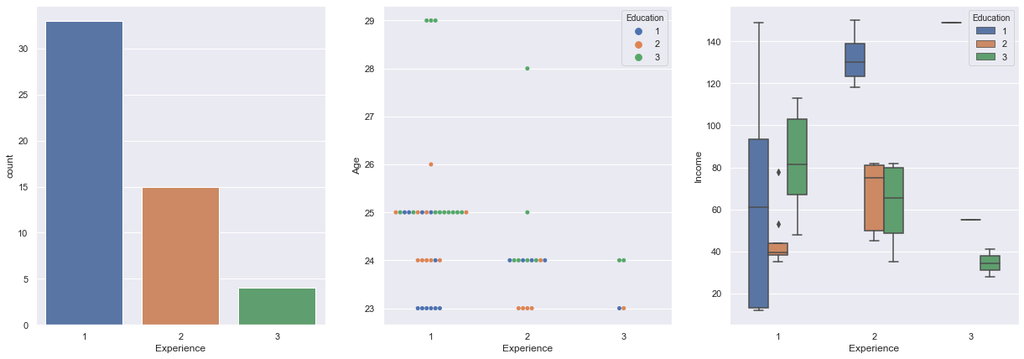

```python
# Above result shows the subset is now having only positive value of dataframe
# Visualizing this subset 'Experience' with education and income

fig, ax = plt.subplots(1, 3)
fig.set_figheight(7)
fig.set_figwidth(21)

sns.countplot(pos_exp['Experience'], ax=ax[0]);
sns.swarmplot(pos_exp['Experience'],pos_exp['Age'],hue=pos_exp['Education'],ax=ax[1]);
sns.boxplot(pos_exp['Experience'],pos_exp['Income'],width=0.6,hue=pos_exp['Education'],ax=ax[2]);
```

From above, following general trends are observed (with exception of outliers / data noise)

- Age is combined reflection of time taken to complete education and years of professional experience
- Experience is proportional to age (subject to completion of education). For example, someone with 1 year of experience is aged higher, if they had taken time to get a higher degree of education
- Similarly, income is in proportion to experience (subject to level of education). Someone with 1 year of experience gets a high income, if they are highly qualified on basis of education

Since these agree with general trends, we can say it is safe to assume that negative sign of experience is a typographical error and converting them to positive value can lead to sensible data

```python
# Data correction - In the parent data frame, replace negative values of "Experience" with positive values

ploan=loan.copy()
ploan.loc[(ploan.Experience<0),'Experience']=ploan['Experience'].multiply(-1)
ploan[ploan<0].info()
```

```
<class 'pandas.core.frame.DataFrame'>
RangeIndex: 5000 entries, 0 to 4999
Data columns (total 14 columns):
 #   Column              Non-Null Count  Dtype
---  ------              --------------  -----
 0   ID                  0 non-null      float64
 1   Age                 0 non-null      float64
 2   Experience          0 non-null      float64
 3   Income              0 non-null      float64
 4   ZIP Code            0 non-null      float64
 5   Family              0 non-null      float64
 6   CCAvg               0 non-null      float64
 7   Education           0 non-null      float64
 8   Mortgage            0 non-null      float64
 9   Personal Loan       0 non-null      float64
 10  Securities Account  0 non-null      float64
 11  CD Account          0 non-null      float64
 12  Online              0 non-null      float64
 13  CreditCard          0 non-null      float64
dtypes: float64(14)
memory usage: 547.0 KB
```

Hence, corrected data frame 'ploan' has neither negative values nor null values. Henceforth, this can be used for further EDA

### 2) Study of data distribution of each attribute

```python
# Before commenting on attributes, check unique values present in 'Family' 'Education' 'Personal loan'
# and in 'Securities Account' 'CD Account' 'Online' and 'CreditCard'

print("Number of unique ZIP Codes:",len(ploan['ZIP Code'].value_counts()),"\n")
print("List of unique values in Family column:\n",ploan['Family'].value_counts(),"\n")
print("List of unique values in Education column:\n",ploan['Education'].value_counts(),"\n")
print("List of unique values in Personal Loan column:\n",ploan['Personal Loan'].value_counts(),"\n")
print("List of unique values in Securities Account column:\n",ploan['Securities Account'].value_counts(),"\n")
print("List of unique values in CD Account column:\n",ploan['CD Account'].value_counts(),"\n")
print("List of unique values in Online column:\n",ploan['Online'].value_counts(),"\n")
print("List of unique values in CreditCard column:\n",loan['CreditCard'].value_counts(),"\n")
```

```
Number of unique ZIP Codes: 467

List of unique values in Family column:
 1    1472
2    1296
4    1222
3    1010
Name: Family, dtype: int64

List of unique values in Education column:
 1    2096
3    1501
2    1403
Name: Education, dtype: int64

List of unique values in Personal Loan column:
 0    4520
1     480
Name: Personal Loan, dtype: int64

List of unique values in Securities Account column:
 0    4478
1     522
Name: Securities Account, dtype: int64

List of unique values in CD Account column:
 0    4698
1     302
Name: CD Account, dtype: int64

List of unique values in Online column:
 1    2984
0    2016
Name: Online, dtype: int64

List of unique values in CreditCard column:
 0    3530
1    1470
Name: CreditCard, dtype: int64
```

- Out of the 14 attributes, 'ID' can be dropped from the analysis since it is just serial number
- Remaining 13 attributes can be classified into two groups

  Group A) Numerical attributes: Age, Experience, Income, CCAvg, Mortgage

  Group B) Categories represented in form of numerical attributes: ZIP Code, Family, Education, Personal loan, Securities Account, CD Account, Online, CreditCard
- Out of this, 'Personal Loan' is the target column for building prediction model

  Accordingly statistical & visualization methods will be used to study their distribution

```python
# Creating two different dataframes for the above two groups
# a) Numerical attributes

loan_n=ploan.drop(['ID','ZIP Code','Family','Education','Personal Loan','Securities Account','CD Account','Online', 'CreditCard'], axis=1, inplace=False)
loan_n
```

|  | Age | Experience | Income | CCAvg | Mortgage |
| --- | --- | --- | --- | --- | --- |
| 0 | 25 | 1 | 49 | 1.6 | 0 |
| 1 | 45 | 19 | 34 | 1.5 | 0 |
| 2 | 39 | 15 | 11 | 1.0 | 0 |
| 3 | 35 | 9 | 100 | 2.7 | 0 |
| 4 | 35 | 8 | 45 | 1.0 | 0 |
| ... | ... | ... | ... | ... | ... |
| 4995 | 29 | 3 | 40 | 1.9 | 0 |
| 4996 | 30 | 4 | 15 | 0.4 | 85 |
| 4997 | 63 | 39 | 24 | 0.3 | 0 |
| 4998 | 65 | 40 | 49 | 0.5 | 0 |
| 4999 | 28 | 4 | 83 | 0.8 | 0 |

5000 rows × 5 columns

```python
# b) Categories represented in form of numerical attributes

loan_c=ploan.drop(['ID','Age','Experience','Income','CCAvg','Mortgage'], axis=1, inplace=False)
loan_c
```

|  | ZIP Code | Family | Education | Personal Loan | Securities Account | CD Account | Online | CreditCard |
| --- | --- | --- | --- | --- | --- | --- | --- | --- |
| 0 | 91107 | 4 | 1 | 0 | 1 | 0 | 0 | 0 |
| 1 | 90089 | 3 | 1 | 0 | 1 | 0 | 0 | 0 |
| 2 | 94720 | 1 | 1 | 0 | 0 | 0 | 0 | 0 |
| 3 | 94112 | 1 | 2 | 0 | 0 | 0 | 0 | 0 |
| 4 | 91330 | 4 | 2 | 0 | 0 | 0 | 0 | 1 |
| ... | ... | ... | ... | ... | ... | ... | ... | ... |
| 4995 | 92697 | 1 | 3 | 0 | 0 | 0 | 1 | 0 |
| 4996 | 92037 | 4 | 1 | 0 | 0 | 0 | 1 | 0 |
| 4997 | 93023 | 2 | 3 | 0 | 0 | 0 | 0 | 0 |
| 4998 | 90034 | 3 | 2 | 0 | 0 | 0 | 1 | 0 |
| 4999 | 92612 | 3 | 1 | 0 | 0 | 0 | 1 | 1 |

5000 rows × 8 columns

#### 2A) Distribution Study of Group A (5 Numerical attributes)

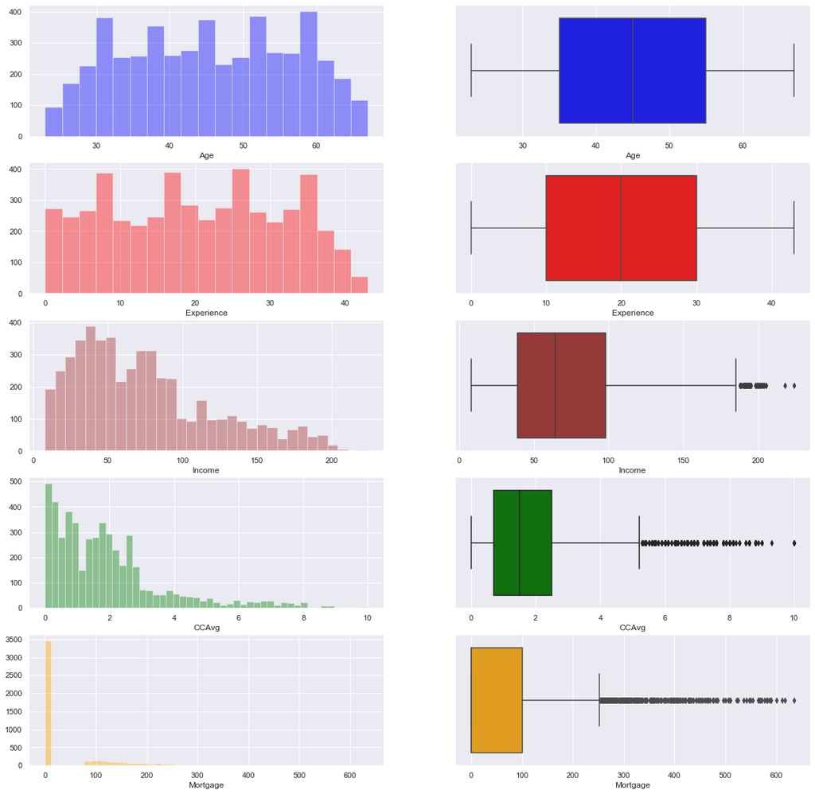

```python
# Plotting distribution using Distplot and Boxplot

fig, ax = plt.subplots(5,2)

fig.set_figheight(20)
fig.set_figwidth(20)

sns.distplot(loan_n['Age'],ax=ax[0,0],color='blue',kde=False);
sns.boxplot(loan_n['Age'],ax=ax[0,1],color='blue');

sns.distplot(loan_n['Experience'],ax=ax[1,0],color='red',kde=False);
sns.boxplot(loan_n['Experience'],ax=ax[1,1],color='red');

sns.distplot(loan_n['Income'],ax=ax[2,0],color='brown',kde=False);
sns.boxplot(loan_n['Income'],ax=ax[2,1],color='brown');

sns.distplot(loan_n['CCAvg'],ax=ax[3,0],color='green',kde=False);
sns.boxplot(loan_n['CCAvg'],ax=ax[3,1],color='green');

sns.distplot(loan_n['Mortgage'],ax=ax[4,0],color='orange',kde=False);
sns.boxplot(loan_n['Mortgage'],ax=ax[4,1],color='orange');
```

```python
# Measure of assymetry in attributes CCAvg, Income, Mortgage

print("Asymmetry in distribution of 'Income':",stats.skew(loan_n['Income']),"\n")
print("Asymmetry in distribution of 'CCAvg':",stats.skew(loan_n['CCAvg']),"\n")
print("Asymmetry in distribution of 'Mortgage':",stats.skew(loan_n['Mortgage']),"\n")
```

```
Asymmetry in distribution of 'Income': 0.8410861846424931

Asymmetry in distribution of 'CCAvg': 1.5979637637001873

Asymmetry in distribution of 'Mortgage': 2.103371065804789
```

Above plots show that:

- Except Age & Experience, other attributes in Group A have outliers
- Income, CCAvg, Mortgage are asymmetric distribution showing right skew (values shown above)

```python
# Calcualtion of Central tendency for Group A
loan_n.describe().round(2)
```

|  | Age | Experience | Income | CCAvg | Mortgage |
| --- | --- | --- | --- | --- | --- |
| count | 5000.00 | 5000.00 | 5000.00 | 5000.00 | 5000.00 |
| mean | 45.34 | 20.13 | 73.77 | 1.94 | 56.50 |
| std | 11.46 | 11.42 | 46.03 | 1.75 | 101.71 |
| min | 23.00 | 0.00 | 8.00 | 0.00 | 0.00 |
| 25% | 35.00 | 10.00 | 39.00 | 0.70 | 0.00 |
| 50% | 45.00 | 20.00 | 64.00 | 1.50 | 0.00 |
| 75% | 55.00 | 30.00 | 98.00 | 2.50 | 101.00 |
| max | 67.00 | 43.00 | 224.00 | 10.00 | 635.00 |

```python
# Mean and Median (50% IQR) are shown above
# Mode is calculated below

print("Mode of 'Age':",stats.mode(loan_n['Age']),"\n")
print("Mode of 'Experience':",stats.mode(loan_n['Experience']),"\n")
print("Mode of 'Income':",stats.mode(loan_n['Income']),"\n")
print("Mode of 'CCAvg':",stats.mode(loan_n['CCAvg']),"\n")
print("Mode of 'Mortgage':",stats.mode(loan_n['Mortgage']),"\n")
```

```
Mode of 'Age': ModeResult(mode=array([35], dtype=int64), count=array([151]))

Mode of 'Experience': ModeResult(mode=array([32], dtype=int64), count=array([154]))

Mode of 'Income': ModeResult(mode=array([44], dtype=int64), count=array([85]))

Mode of 'CCAvg': ModeResult(mode=array([0.3]), count=array([241]))

Mode of 'Mortgage': ModeResult(mode=array([0], dtype=int64), count=array([3462]))
```

#### 2B) Distribution Study of Group B (8 Categories represented as numerical attributes)

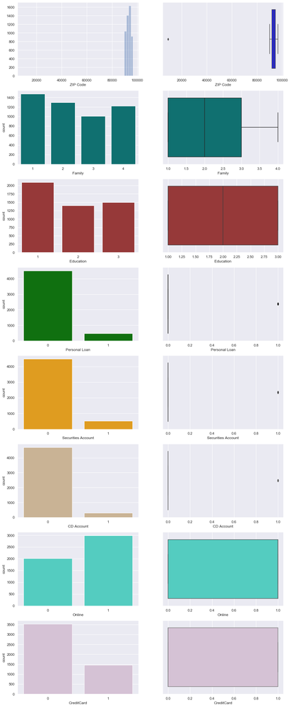

```python
# Plotting Group B distribution using Countplot and Boxplot

fig, ax = plt.subplots(8,2)

fig.set_figheight(40)
fig.set_figwidth(15)

sns.distplot(loan_c['ZIP Code'],ax=ax[0,0],kde=False);
sns.boxplot(loan_c['ZIP Code'],ax=ax[0,1],color='blue');

sns.countplot(loan_c['Family'],ax=ax[1,0],color='teal');
sns.boxplot(loan_c['Family'],ax=ax[1,1],color='teal');

sns.countplot(loan_c['Education'],ax=ax[2,0],color='brown');
sns.boxplot(loan_c['Education'],ax=ax[2,1],color='brown');

sns.countplot(loan_c['Personal Loan'],ax=ax[3,0],color='green');
sns.boxplot(loan_c['Personal Loan'],ax=ax[3,1],color='green');

sns.countplot(loan_c['Securities Account'],ax=ax[4,0],color='orange');
sns.boxplot(loan_c['Securities Account'],ax=ax[4,1],color='orange');

sns.countplot(loan_c['CD Account'],ax=ax[5,0],color='tan');
sns.boxplot(loan_c['CD Account'],ax=ax[5,1],color='tan');

sns.countplot(loan_c['Online'],ax=ax[6,0],color='turquoise');
sns.boxplot(loan_c['Online'],ax=ax[6,1],color='turquoise');

sns.countplot(loan_c['CreditCard'],ax=ax[7,0],color='thistle');
sns.boxplot(loan_c['CreditCard'],ax=ax[7,1],color='thistle');
```

```python
# Central tendency is checked by mode

'ZIP Code','Family','Education','Personal Loan','Securities Account','CD Account','Online', 'CreditCard'

print("Mode of 'ZIP Code':",stats.mode(loan_c['ZIP Code']),"\n")
print("Mode of 'Family':",stats.mode(loan_c['Family']),"\n")
print("Mode of 'Education':",stats.mode(loan_c['Education']),"\n")
print("Mode of 'Personal Loan':",stats.mode(loan_c['Personal Loan']),"\n")
print("Mode of 'Securities Account':",stats.mode(loan_c['Securities Account']),"\n")
print("Mode of 'CD Account':",stats.mode(loan_c['CD Account']),"\n")
print("Mode of 'Online':",stats.mode(loan_c['Online']),"\n")
print("Mode of 'CreditCard':",stats.mode(loan_c['CreditCard']),"\n")
```

```
Mode of 'ZIP Code': ModeResult(mode=array([94720], dtype=int64), count=array([169]))

Mode of 'Family': ModeResult(mode=array([1], dtype=int64), count=array([1472]))

Mode of 'Education': ModeResult(mode=array([1], dtype=int64), count=array([2096]))

Mode of 'Personal Loan': ModeResult(mode=array([0], dtype=int64), count=array([4520]))

Mode of 'Securities Account': ModeResult(mode=array([0], dtype=int64), count=array([4478]))

Mode of 'CD Account': ModeResult(mode=array([0], dtype=int64), count=array([4698]))

Mode of 'Online': ModeResult(mode=array([1], dtype=int64), count=array([2984]))

Mode of 'CreditCard': ModeResult(mode=array([0], dtype=int64), count=array([3530]))
```

Mode values can be seen from above result

Also the plots show that:

- ZIP Code has outliers or some error values which lie much outside the range of 90000's. Maximum number of customers (169) are from area 94720
- No outliers in Family, Education attributes
- For Personal Loan, Securites Account, CD Account, the percentage of customers who have/ have taken them is 9.6%, 10.4% and 6% respectively. Hence, they are represented as outliers

### 3) Target column distribution

#### 3A) Based on Group A attributes (numerical)

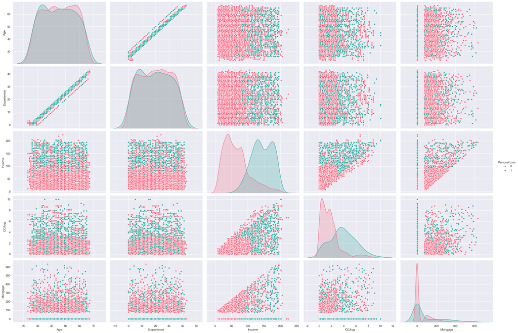

```python
# Target column is Personal loan
# Distribution is already discussed in above plots (only 9.6% of customers have availed personal loan in previous campaign)
# Basic EDA related to this column and other independent attributes is shown below
# Pair plot used with hue parameter = Personal Loan

loan_n1=ploan.drop(['ID','ZIP Code','Family','Education','Securities Account','CD Account','Online', 'CreditCard'], axis=1, inplace=False)
sns.pairplot(loan_n1,hue='Personal Loan',height=3.5,aspect=1.5,palette="husl");
```

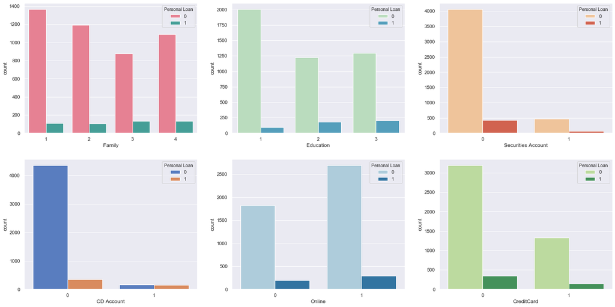

```python
# Target column is Personal loan
# Distribution is already discussed in Section 2B (only 9.6% of customers have availed personal loan in previous campaign)
# Basic EDA related to this column and other independent attributes in Group B is shown below
# Count plot used with hue parameter = Personal Loan

fig,ax = plt.subplots(2,3)
fig.set_figheight(12)
fig.set_figwidth(24)

sns.countplot(loan_c['Family'],hue=loan_c['Personal Loan'],palette='husl',ax=ax[0,0]);
sns.countplot(loan_c['Education'],hue=loan_c['Personal Loan'],palette='GnBu',ax=ax[0,1]);
sns.countplot(loan_c['Securities Account'],hue=loan_c['Personal Loan'],palette='OrRd',ax=ax[0,2]);
sns.countplot(loan_c['CD Account'],hue=loan_c['Personal Loan'],palette='muted',ax=ax[1,0]);
sns.countplot(loan_c['Online'],hue=loan_c['Personal Loan'],palette='Paired',ax=ax[1,1]);
sns.countplot(loan_c['CreditCard'],hue=loan_c['Personal Loan'],palette='YlGn',ax=ax[1,2]);
```

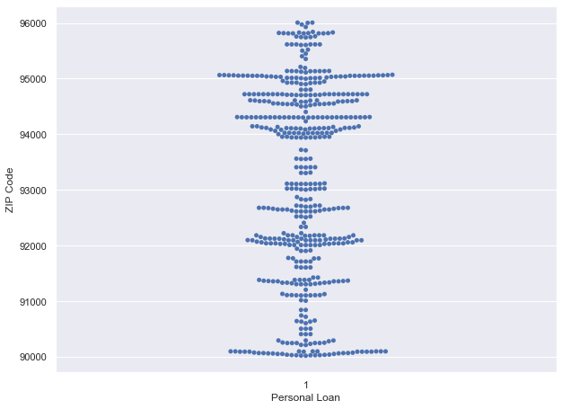

```python
# Creating dataframe with only customers who availed personal loan
# Checking influence of ZIP Code, ZIP Code and Income

loan_pl1=ploan[ploan['Personal Loan']==1]
loan_pl1.shape

fig,ax = plt.subplots(1)
fig.set_figheight(7.5)
fig.set_figwidth(10)
sns.swarmplot(loan_pl1['Personal Loan'],loan_pl1['ZIP Code']);
```

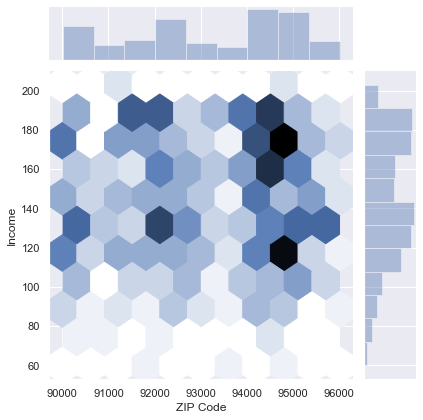

```python
sns.jointplot(loan_pl1['ZIP Code'],loan_pl1['Income'],kind='hex');
```

Above plots customers belonging to 4 to 5 areas / ZIP Codes have more customer population who availed personal loans. Ans also, these customers have income more than 100k dollars.

#### 3C) Combined correlation - Both Group A and Group B

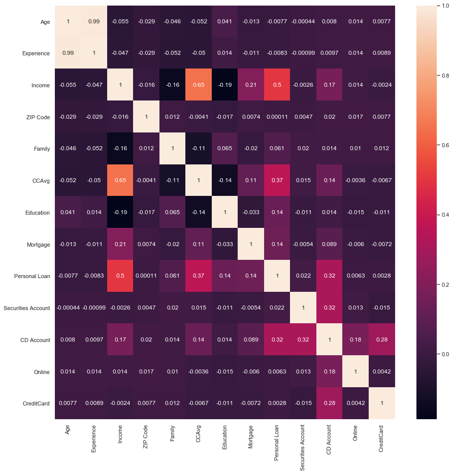

```python
# Correlation factor is plotted using heat map

loan_plot=ploan.drop(['ID'], axis=1,inplace=False)
corr_1=loan_plot.corr()

plt.figure(figsize = (15,15))
sns.heatmap(corr_1, annot=True);
```

Based on all the above study, only the below influential attributes will be taken over building prediction model

- Income
- CCAvg
- Education
- Mortgage
- CD Acount
- ZIP Code (based on hex & swarm plot, not correlation table)
- Personal Loan (target attribute)

### 4) Spliting data into train, test set (70:30)

```python
# Creating dataframe with only influential attributes mentioned in Section 3

loan_model=ploan.drop(['ID','Age','Experience','Family','Securities Account',
            'Online','CreditCard'], axis=1, inplace=False)
loan_model.shape
```

```
(5000, 7)
```

```python
corr_2=loan_model.corr()
corr_2
```

|  | Income | ZIP Code | CCAvg | Education | Mortgage | Personal Loan | CD Account |
| --- | --- | --- | --- | --- | --- | --- | --- |
| Income | 1.000000 | -0.016410 | 0.645984 | -0.187524 | 0.206806 | 0.502462 | 0.169738 |
| ZIP Code | -0.016410 | 1.000000 | -0.004061 | -0.017377 | 0.007383 | 0.000107 | 0.019972 |
| CCAvg | 0.645984 | -0.004061 | 1.000000 | -0.136124 | 0.109905 | 0.366889 | 0.136534 |
| Education | -0.187524 | -0.017377 | -0.136124 | 1.000000 | -0.033327 | 0.136722 | 0.013934 |
| Mortgage | 0.206806 | 0.007383 | 0.109905 | -0.033327 | 1.000000 | 0.142095 | 0.089311 |
| Personal Loan | 0.502462 | 0.000107 | 0.366889 | 0.136722 | 0.142095 | 1.000000 | 0.316355 |
| CD Account | 0.169738 | 0.019972 | 0.136534 | 0.013934 | 0.089311 | 0.316355 | 1.000000 |

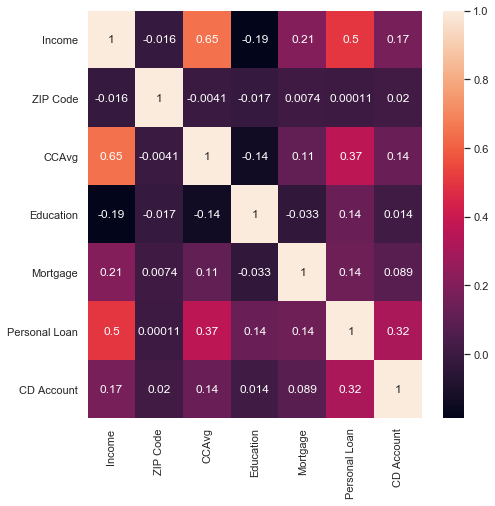

```python
plt.figure(figsize = (7.5,7.5))
sns.heatmap(corr_2, annot=True);
```

```python
#Splitting data

from sklearn.model_selection import train_test_split

X = loan_model.drop('Personal Loan',axis=1)
Y = loan_model['Personal Loan']

x_train, x_test, y_train, y_test = train_test_split(X, Y, test_size=0.3, random_state=1)

x_train.head()
```

|  | Income | ZIP Code | CCAvg | Education | Mortgage | CD Account |
| --- | --- | --- | --- | --- | --- | --- |
| 1334 | 35 | 94304 | 1.3 | 1 | 0 | 0 |
| 4768 | 39 | 93118 | 2.0 | 2 | 0 | 0 |
| 65 | 131 | 91360 | 3.8 | 1 | 0 | 0 |
| 177 | 65 | 94132 | 1.8 | 2 | 244 | 0 |
| 4489 | 21 | 95518 | 0.2 | 2 | 0 | 0 |

```python
x_test.head()
```

|  | Income | ZIP Code | CCAvg | Education | Mortgage | CD Account |
| --- | --- | --- | --- | --- | --- | --- |
| 2764 | 84 | 91320 | 2.9 | 3 | 105 | 0 |
| 4767 | 45 | 90639 | 0.9 | 1 | 101 | 0 |
| 3814 | 35 | 94304 | 1.3 | 1 | 0 | 0 |
| 3499 | 114 | 94550 | 0.3 | 1 | 286 | 0 |
| 2735 | 70 | 92131 | 2.6 | 2 | 165 | 0 |

```python
#Checking split of data

print("{0:0.1f}% data is in training set".format((len(x_train)/len(loan_model.index)) * 100))
print("{0:0.1f}% data is in test set".format((len(x_test)/len(loan_model.index)) * 100))
```

```
70.0% data is in training set
30.0% data is in test set
```

```python
# Checking split of target column

print("Original Personal Loan '1' Values   : {0} ({1:0.1f}%)".format(len(loan_model.loc[loan_model['Personal Loan'] == 1]), (len(loan_model.loc[loan_model['Personal Loan'] == 1])/len(loan_model.index)) * 100))
print("Original Personal Loan '0' Values   : {0} ({1:0.1f}%)".format(len(loan_model.loc[loan_model['Personal Loan'] == 0]), (len(loan_model.loc[loan_model['Personal Loan'] == 0])/len(loan_model.index)) * 100))
print("")
print("Training Personal Loan '1' Values   : {0} ({1:0.1f}%)".format(len(y_train[y_train[:] == 1]), (len(y_train[y_train[:] == 1])/len(y_train)) * 100))
print("Training Personal Loan '0' Values   : {0} ({1:0.1f}%)".format(len(y_train[y_train[:] == 0]), (len(y_train[y_train[:] == 0])/len(y_train)) * 100))
print("")
print("Test Personal Loan '1' Values       : {0} ({1:0.1f}%)".format(len(y_test[y_test[:] == 1]), (len(y_test[y_test[:] == 1])/len(y_test)) * 100))
print("Test Personal Loan '0' Values       : {0} ({1:0.1f}%)".format(len(y_test[y_test[:] == 0]), (len(y_test[y_test[:] == 0])/len(y_test)) * 100))
print("")
```

```
Original Personal Loan '1' Values   : 480 (9.6%)
Original Personal Loan '0' Values   : 4520 (90.4%)

Training Personal Loan '1' Values   : 331 (9.5%)
Training Personal Loan '0' Values   : 3169 (90.5%)

Test Personal Loan '1' Values       : 149 (9.9%)
Test Personal Loan '0' Values       : 1351 (90.1%)
```

From above result, we see that the percentage is maintained similar across original, train and test data

### 5) Prediction using different models

#### 5A) Logistic Regression

```python
# For sake of training, replace 0 values with mean

from sklearn.impute import SimpleImputer
rep_0 = SimpleImputer(missing_values=0, strategy="mean")
cols=x_train.columns
x_train = pd.DataFrame(rep_0.fit_transform(x_train))
x_test = pd.DataFrame(rep_0.fit_transform(x_test))

x_train.columns = cols
x_test.columns = cols

x_train.head()
```

|  | Income | ZIP Code | CCAvg | Education | Mortgage | CD Account |
| --- | --- | --- | --- | --- | --- | --- |
| 0 | 35.0 | 94304.0 | 1.3 | 1.0 | 181.659259 | 1.0 |
| 1 | 39.0 | 93118.0 | 2.0 | 2.0 | 181.659259 | 1.0 |
| 2 | 131.0 | 91360.0 | 3.8 | 1.0 | 181.659259 | 1.0 |
| 3 | 65.0 | 94132.0 | 1.8 | 2.0 | 244.000000 | 1.0 |
| 4 | 21.0 | 95518.0 | 0.2 | 2.0 | 181.659259 | 1.0 |

```python
from sklearn import metrics
from sklearn.linear_model import LogisticRegression
from sklearn.metrics import average_precision_score, confusion_matrix, plot_confusion_matrix

model = LogisticRegression(solver="liblinear")
model.fit(x_train, y_train)
```

```
LogisticRegression(C=1.0, class_weight=None, dual=False, fit_intercept=True,
                   intercept_scaling=1, l1_ratio=None, max_iter=100,
                   multi_class='auto', n_jobs=None, penalty='l2',
                   random_state=None, solver='liblinear', tol=0.0001, verbose=0,
                   warm_start=False)
```

```python
y_predict = model.predict(x_test)
y_predict
```

```
array([0, 0, 0, ..., 0, 0, 0], dtype=int64)
```

```python
# Logistic Regression Model score
model_score = model.score(x_test, y_test)
print(model_score)
```

```
0.9086666666666666
```

#### 5B) K-NN model

```python
from sklearn.neighbors import KNeighborsClassifier
from scipy.stats import zscore

#Conversion to Z-scale

XScaled  = X.apply(zscore)
XScaled.describe()
```

|  | Income | ZIP Code | CCAvg | Education | Mortgage | CD Account |
| --- | --- | --- | --- | --- | --- | --- |
| count | 5.000000e+03 | 5.000000e+03 | 5.000000e+03 | 5.000000e+03 | 5.000000e+03 | 5.000000e+03 |
| mean | 1.939449e-16 | 1.513445e-15 | -2.078338e-17 | -6.315837e-16 | 2.810197e-16 | 4.426903e-16 |
| std | 1.000100e+00 | 1.000100e+00 | 1.000100e+00 | 1.000100e+00 | 1.000100e+00 | 1.000100e+00 |
| min | -1.428969e+00 | -3.951919e+01 | -1.108987e+00 | -1.049078e+00 | -5.555239e-01 | -2.535403e-01 |
| 25% | -7.554825e-01 | -5.851619e-01 | -7.084116e-01 | -1.049078e+00 | -5.555239e-01 | -2.535403e-01 |
| 50% | -2.123482e-01 | 1.340930e-01 | -2.506106e-01 | 1.417029e-01 | -5.555239e-01 | -2.535403e-01 |
| 75% | 5.263146e-01 | 6.860245e-01 | 3.216407e-01 | 1.332484e+00 | 4.375576e-01 | -2.535403e-01 |
| max | 3.263712e+00 | 1.648959e+00 | 4.613525e+00 | 1.332484e+00 | 5.688108e+00 | 3.944146e+00 |

```python
x_train_k, x_test_k, y_train_k, y_test_k = train_test_split(XScaled, Y, test_size=0.30, random_state=1)

print("{0:0.1f}% data is in training set".format((len(x_train_k)/len(loan_model.index)) * 100))
print("{0:0.1f}% data is in test set".format((len(x_test_k)/len(loan_model.index)) * 100))
```

```
70.0% data is in training set
30.0% data is in test set
```

```python
NNH = KNeighborsClassifier(n_neighbors= 5 , weights = 'distance' )
NNH.fit(x_train_k, y_train_k)
```

```
KNeighborsClassifier(algorithm='auto', leaf_size=30, metric='minkowski',
                     metric_params=None, n_jobs=None, n_neighbors=5, p=2,
                     weights='distance')
```

```python
#KNN Model score

NNH.score(x_test_k, y_test_k)
```

```
0.954
```

#### 5C) Naive Bayes Model

```python
from sklearn.naive_bayes import GaussianNB

pl_model=GaussianNB()
pl_model.fit(x_train, y_train.ravel())
```

```
GaussianNB(priors=None, var_smoothing=1e-09)
```

```python
#Naive Bayes Model score

pl_test_predict = pl_model.predict(x_test)
metrics.accuracy_score(y_test, pl_test_predict)
```

```
0.884
```

### 6) Print Confusion matrix for the three models

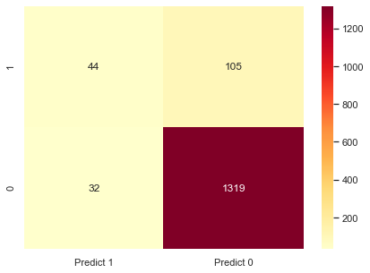

```python
# Confusion matrix for Logistic Regression

cm1=metrics.confusion_matrix(y_test, y_predict, labels=[1, 0])

df_cm1 = pd.DataFrame(cm1, index = [i for i in ["1","0"]],
                  columns = [i for i in ["Predict 1","Predict 0"]])
plt.figure(figsize = (7,5))
sns.heatmap(df_cm1, annot=True,fmt='g',cmap="YlOrRd");
```

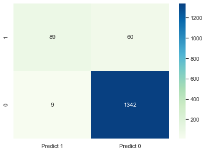

```python
# Confusion matrix for KNN model

predicted_labels = NNH.predict(x_test_k)
cm2=metrics.confusion_matrix(y_test, predicted_labels, labels=[1,0])
df_cm2 = pd.DataFrame(cm2, index = [i for i in ["1","0"]],
                  columns = [i for i in ["Predict 1","Predict 0"]])
plt.figure(figsize = (7,5))
sns.heatmap(df_cm2, annot=True,fmt='g',cmap='GnBu');
```

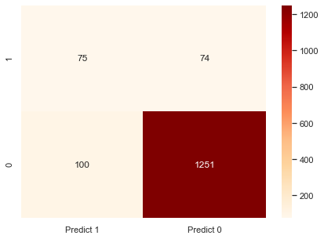

```python
# Confusion matrix for Naives Bayes model

cm3=metrics.confusion_matrix(y_test, pl_test_predict, labels=[1,0])
df_cm3 = pd.DataFrame(cm3, index = [i for i in ["1","0"]],
                  columns = [i for i in ["Predict 1","Predict 0"]])
plt.figure(figsize = (7,5))
sns.heatmap(df_cm3, annot=True,fmt='g',cmap='OrRd');
```

### 7) Deciding the best model

```python
# Report for logistic regression model


print("Model score is:",model.score(x_test, y_test),"\n")
print(metrics.classification_report(y_test, y_predict, labels=[1, 0]))
```

```
Model score is: 0.9086666666666666

              precision    recall  f1-score   support

           1       0.58      0.30      0.39       149
           0       0.93      0.98      0.95      1351

    accuracy                           0.91      1500
   macro avg       0.75      0.64      0.67      1500
weighted avg       0.89      0.91      0.90      1500
```

```python
# Report for KNN model

print("Model score is:",NNH.score(x_test_k, y_test_k),"\n")
print(metrics.classification_report(y_test, predicted_labels, labels=[1, 0]))
```

```
Model score is: 0.954

              precision    recall  f1-score   support

           1       0.91      0.60      0.72       149
           0       0.96      0.99      0.97      1351

    accuracy                           0.95      1500
   macro avg       0.93      0.80      0.85      1500
weighted avg       0.95      0.95      0.95      1500
```

```python
# Report for Naive Bayes model

print("Model score is:",metrics.accuracy_score(y_test, pl_test_predict),"\n")
print(metrics.classification_report(y_test, pl_test_predict, labels=[1, 0]))
```

```
Model score is: 0.884

              precision    recall  f1-score   support

           1       0.43      0.50      0.46       149
           0       0.94      0.93      0.93      1351

    accuracy                           0.88      1500
   macro avg       0.69      0.71      0.70      1500
weighted avg       0.89      0.88      0.89      1500
```

Based on model scores, precision and recall values, we see that KNN model is having higher model score, higher precision (91%) and low recall (60%).

Hence, for this dataset, KNN model can be considered as the best model